# Comparing Means

APHS 20203

## Big Picture - What Do We Want to Know

1. What is epidemiology?
2. In epidemiologic studies, what do we typically want to know?
3. What is the statistical term for these quantities?
4. Can we measure these quantities directly? Why or why not?

## Example: What Do We Want to Know?

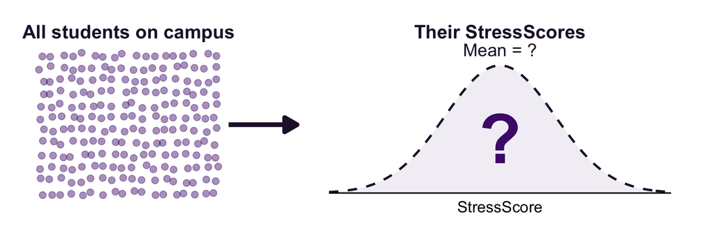

**Research question:** What is the mean StressScore for all students on campus?

## Example: What We Actually Measure

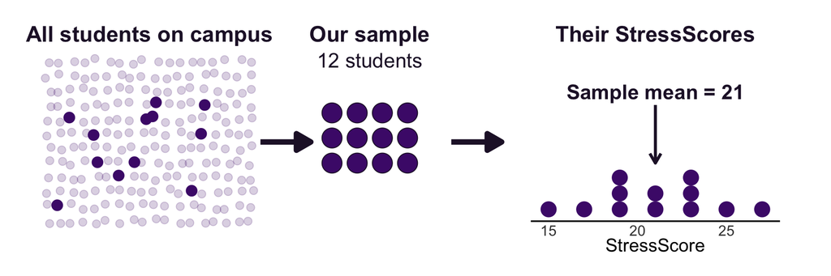

## Why Do We Test Hypotheses?

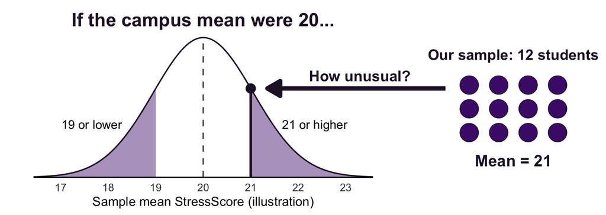

> **Example question we *can* answer:** If the campus mean were 20 and the model assumptions hold, how often would a sample mean be at least 1 point from 20?

## Four Steps of Hypothesis Testing

1. **Assume a model.** The model describes how we assume the data were generated. The null hypothesis (H₀) is one part of it.
2. **Select an alpha level.** Choose the cutoff for rejecting H₀ before seeing the data.
3. **Calculate a test statistic.** Measure how far our data are from what H₀ predicts.
4. **Calculate a p-value.** Compare the test statistic with the distribution the model predicts if H₀ is true.

Together, these steps make up a **statistical test**. The test is usually named after its statistic and reference distribution (*t* test, *F* test).

## What Determines Which Statistical Test We Use?

1. **What do we want to know about the population?** We might compare one group with a reference value, compare two or more groups, or look for a change over time.
2. **What kind of data do we have?** Measurements (often summarized with means), counts, and yes-or-no outcomes (often summarized with proportions) can call for different models.
3. **How did we collect the data?** Observations may come from separate individuals, matched pairs, or repeated measurements on the same individual.

## Which Tests Can We Use to Compare Means?

| What do we want to know? | Test | Statistic |
| --- | --- | --- |
| Does a population mean differ from a fixed reference value? | One-sample t-test | *t* |
| Do the population means differ between two independent groups? | Independent-samples t-test | *t* |
| Does the population mean change differ from zero when the same people are measured twice? | Paired t-test | *t* |
| Do the population means differ across three or more independent groups? | One-way ANOVA | *F* |

## Why Do We Need Different t-Tests?

All three tests measure how many **estimated standard errors** our estimate falls above or below the null value. The design determines how we calculate that standard error.

| Test | What determines the standard error? |
| --- | --- |
| One-sample | The spread and number of independent observations. The reference value is fixed. |
| Independent-samples | The spread and sample size in each group. Both means contribute uncertainty. |
| Paired | The spread of the within-pair differences and the number of independent pairs. |

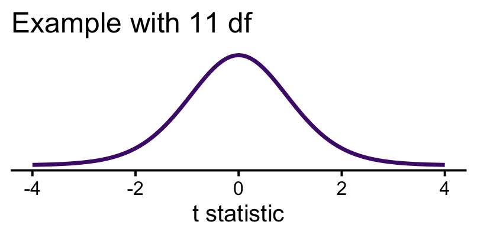

All three use a *t* reference distribution. Its shape depends on the degrees of freedom.

## One Researcher, Three Designs

Last time, our campus health researcher asked whether the mean StressScore differed from **20 points**. She could study campus stress with three different designs:

1. Measure one sample of students and compare its mean with 20. This was last time’s design.
2. Recruit separate samples of students from two campuses and compare their means.
3. Measure the **same students** before and after finals and compare the two occasions.

**Think to yourself.** In each design, what is being compared with what? Which students supply the scores on each side?

## What Do the Three Designs Look Like?

Each dot is one student’s StressScore. In the third design, a line joins the two scores from the same student.

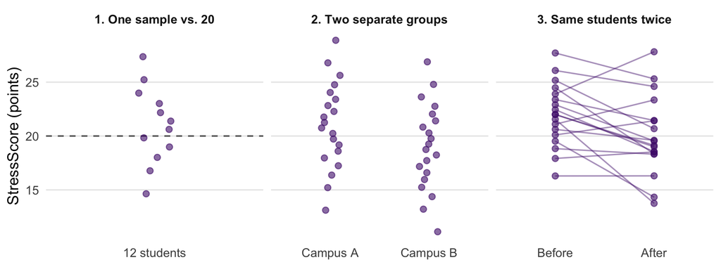

**In each panel, what does one student contribute to the analysis?**

## Exercise: Which T-Test Fits?

1. Open the Comparing Means Excel file.
2. Match each study design (A–C) with a test (1–3). For each match, explain what one student contributes to the analysis.

| Study design | Test choices |
| --- | --- |
| **A.** Compare one sample’s mean StressScore with 20 points. | **1.** Paired t-test |
| **B.** Compare mean StressScores for different students at two campuses. | **2.** One-sample t-test |
| **C.** Compare StressScores before and after finals for the same students. | **3.** Independent-samples t-test |

## One Sample: Is the Mean Different From 20?

Open the **One Sample** tab. Our 12 students averaged **21 StressScore points** (sample SD 3.64).

1. **Assume a model.** Under H₀, the campus mean is 20. Assume independent observations from an approximately normal population.
2. **Select α.** Before seeing the results, we chose .05 for a two-sided test.
3. **Calculate *t*.** With a standard error of 1.05 points, the sample mean is (21 − 20) ÷ 1.05 ≈ **0.95 standard errors above 20**.
4. **Calculate and interpret *p*.** With 11 degrees of freedom, *p* = .362. At α = .05, we fail to reject H₀.

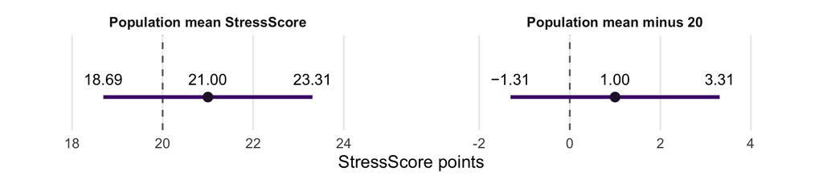

Why does finding **20** in the first 95% interval give the same decision as finding **0** in the second?

## Paired Samples: Did Scores Change After Finals?

In a hypothetical follow-up, **18 students** report a score **before** and **after** finals. Each student’s change is **after minus before**.

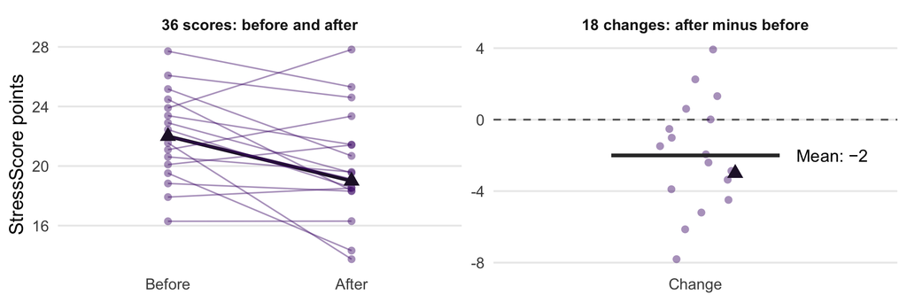

The triangle is one student: 22 before, 19 after, a change of **−3**. The **paired t-test** asks whether the mean of the 18 changes differs from **0**.

## Paired Samples: What Did We Find?

Each of the 18 students contributes **one change** (after minus before). Use the **Paired Samples** tab in Excel.

1. **Assume a model.** H₀ says the population mean change is zero. Assume changes are independent across students and approximately normally distributed.
2. **Select α.** We chose .05 for a two-sided test.
3. **Calculate the statistic.** Changes averaged −2 points (SD = 3). Their standard error is 3/√18 ≈ 0.71 points, giving *t*(17) = −2.83.
4. **Interpret the p-value.** If the population mean change were zero and the assumptions held, about **1.2%** of such samples would give a *t* this far from zero or farther in either direction.

At α = .05 we reject H₀. Students averaged **2 points lower after finals** (95% CI for mean change −3.49 to −0.51).

## Independent Samples: Do the Campus Means Differ?

Campus A averaged **21 points** and Campus B averaged **19**. Each campus recruited 20 different students, with a sample SD of 4 points at each campus. Use the **Independent Samples** tab.

1. **Assume a model.** H₀ says the campus population means are equal. The pooled test assumes independent observations, approximately normal scores within each campus, and equal population variances.
2. **Select α.** We chose .05 for a two-sided test.
3. **Calculate the statistic.** A minus B is +2 points. Its standard error is 1.26 points, giving *t*(38) = 1.58.
4. **Interpret the p-value.** Under H₀ and the model assumptions, about **12.2%** of such samples would give a *t* at least this far from zero in either direction.

At α = .05 we fail to reject H₀. The data give insufficient evidence that the campus population means differ.

## Independent Samples: Explain the Result

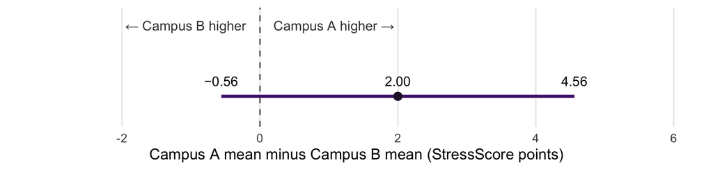

On the **Independent Samples** tab, explain the result to a campus health director. Include the **estimated difference** and the **range of differences** compatible with the data. What would you need to know to judge whether the difference matters?

## What Does the Number in Parentheses Tell Us?

Someone reports a **pooled independent-samples t-test** as *t*(38) = 1.58. Each group loses one degree of freedom when it estimates its own mean, so df = **(n₁ − 1) + (n₂ − 1)**, the total number of students minus 2.

1. How many students were included **in total**?
2. Can you recover the size of each group from 38 alone?
3. How would your answer change if the report said **paired t-test**?

## Which Test Fits the Design?

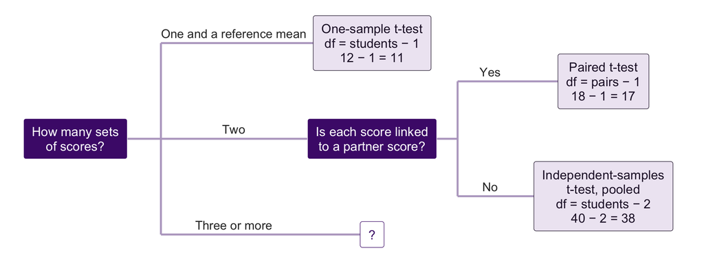

Suppose different people took part in each of **three programs**. Which branch would you follow?

## What Does a One-Way ANOVA Compare?

A **one-way analysis of variance (ANOVA)** compares population means across levels of one grouping variable.

1. **Assume a model.** H₀ says the population means are equal at every level. Assume independent observations, approximately normal outcomes within each level, and equal population variances.
2. **Select α.** Choose the cutoff before examining the data.
3. **Calculate F.** Compare variation between the level means with variation among individuals within levels. Greater separation relative to the within-level spread gives a larger F.
4. **Calculate the p-value.** The *t* statistic can be positive or negative. *F* is nonnegative. Under the null model, the p-value is the area **at or above the observed F** in its reference distribution.

## Question: Which Study Gives the Larger F?

Two hypothetical studies have the **same three sample means** (22, 20, and 18). Only the spread of scores within each level differs.

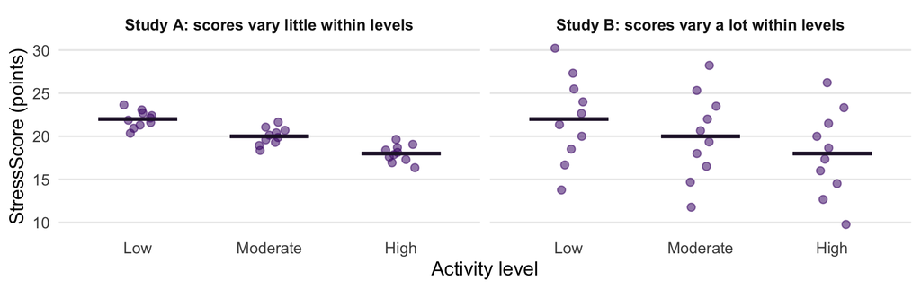

F = variation **between** the level means ÷ variation **within** the levels. Which study gives the larger F, and why?

## Practice: What Does the p-Value Mean?

In a hypothetical comparison of three programs, *F*(2, 57) = 8.75 and *p* < .001. Which statement could you report?

A. If the three population means were equal and the model assumptions held, fewer than 1 in 1,000 such studies would give an F of 8.75 or larger.

B. There is less than a 1 in 1,000 chance that the three population means are equal.

C. Every pair of programs differs by a meaningful amount.

## Try It: The ANOVA Calculator

This is the calculator for your project’s H2 analysis. Enter the hypothetical program study:

| Program | n | Mean StressScore | SD |
| --- | --- | --- | --- |
| Low | 20 | 22 | 4 |
| Moderate | 20 | 21 | 4 |
| High | 20 | 17 | 4 |

Select **SD**, leave unused rows blank, and choose **Compute**. [Open the summary-data ANOVA calculator](https://statpages.info/anova1sm.html)

Check that you get *F*(2, 57) = 8.75, then complete **Activity, exercise 2**.

## Which Programs Differ?

The overall F test asks whether all the population means are equal. Use the calculator’s Tukey output, or **Activity, exercises 3 and 4**, to interpret the program study.

- A **pairwise difference** gives the direction and size of a specific comparison. Read the program labels in subtraction order.
- **Tukey-adjusted 95% intervals** account for examining all pairs together. Under the model, the procedure covers all the population differences simultaneously in 95% of repeated studies.
- Compare the interval with **zero** to assess direction and with a **meaningful difference** to judge practical importance.

## Key Points

- **Start with the design.** One sample contributes scores, paired measurements contribute changes, and independent groups contribute separate means.
- **With three or more groups, start with the overall F test.** It tells you whether at least one population mean differs. Follow-up comparisons tell you which pairs differ and by how much.
- **Interpret a p-value under the null model.** State the null in context, then describe the probability of a test statistic at least as extreme as the one observed. For a two-sided *t* test, count both tails. For ANOVA, count the upper F tail.
- **Report the estimate and its uncertainty.** The sign gives direction, the interval gives a range of compatible differences, and a subject-matter benchmark helps judge importance.